# imageClassification

First import required libraries

```python
import numpy as np
import keras as k
import tensorflow as tf
import matplotlib.pyplot as plt
from keras.models import Sequential
from keras.layers import Conv2D, MaxPooling2D, Flatten, Dense, Rescaling, Dropout, RandomRotation, RandomZoom
from keras.utils import image_dataset_from_directory
from keras.applications.mobilenet_v2 import MobileNetV2
```

Set up parameters and create the data sets. This [data set](https://www.kaggle.com/datasets/koryakinp/fingers) is a large set of image of hands holding up any nubmer of fingers. I reorganized all the files into folders for each class as well as ignoring the left vs right hand images. The dataset specifies the left vs right hand images are generated by mirroring the image and thus I dont care to differentiate between them and only use it to cut out a data augmentation step.

```python
train_dir = 'data/train'
test_dir = 'data/test'
image_width = 128
image_height = 128

train_ds = image_dataset_from_directory(train_dir, seed=0, image_size=(image_height, image_width), batch_size=30, validation_split=0.2, subset="training")
val_ds = image_dataset_from_directory(train_dir, seed=0, image_size=(image_height, image_width), batch_size=30, validation_split=0.2, subset="validation")
test_ds = image_dataset_from_directory(test_dir, seed=0, image_size=(image_height, image_width), batch_size=30)

class_names = ['0','1','2','3','4','5']

train_ds = train_ds.cache().prefetch(buffer_size=tf.data.AUTOTUNE)
val_ds = val_ds.cache().prefetch(buffer_size=tf.data.AUTOTUNE)
test_ds = test_ds.cache().prefetch(buffer_size=tf.data.AUTOTUNE)
```

```
Found 18000 files belonging to 6 classes.
Using 14400 files for training.
Found 18000 files belonging to 6 classes.
Using 3600 files for validation.
Found 3600 files belonging to 6 classes.
```

Showing some examples from the training data set.

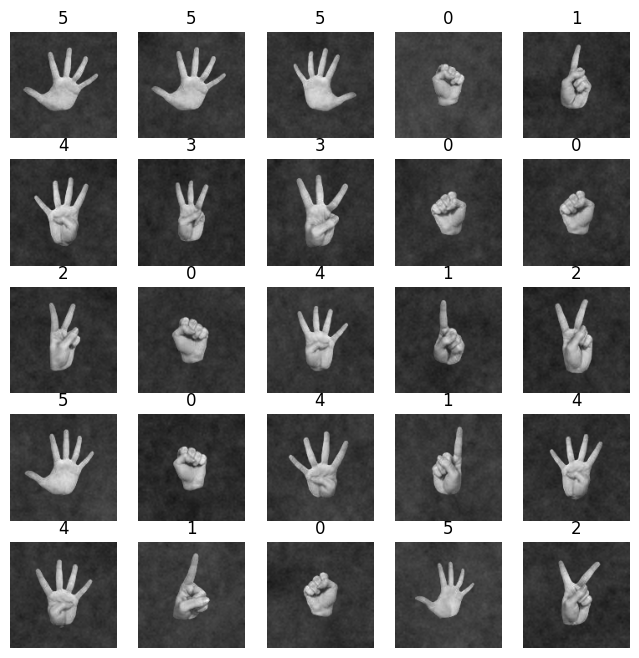

```python
plt.figure(figsize=(8, 8))
for images, labels in train_ds.take(1):
  for i in range(25):
    ax = plt.subplot(5, 5, i + 1)
    plt.imshow(images[i].numpy().astype("uint8"))
    plt.title(class_names[labels[i]])
    plt.axis("off")
```

This graph shows the reletivly even distribution of the classes.

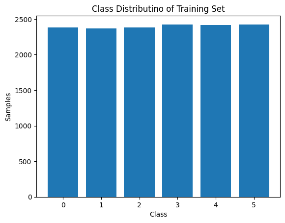

```python
train_counts = np.zeros(len(class_names))
for _,labels in train_ds:
    for label in labels:
        train_counts[label] += 1
plt.bar(class_names,train_counts)
plt.title('Class Distributino of Training Set')
plt.xlabel('Class')
plt.ylabel('Samples')
plt.show()
```

This first model is just a simple sequential model. The first few layers are for data augementation by applying random zoom and rotaion. I dont do a horizontal filp as the data set includes imagaes that are already fliped horizontaly to represent left and right hands. Then a rescaling layer. And finaly a flatten and 3 densly connected layers connected to the output layer.

```python
seq = Sequential([
    RandomRotation(0.2, input_shape=(image_width,image_height,3)),
    RandomZoom(0.2),
    Rescaling(1./255),
    Flatten(),
    Dense(units=128, activation='relu'),
    Dense(units=64, activation='relu'),
    Dense(units=32, activation='relu'),
    Dense(units=len(class_names)),
])
seq.build()
seq.summary()
```

[output not shown]

This next model is the CNN model. It has the same data augementation and rescaling layers, followed by 2 sets of a 2D convolution layer and a 2D pooling layer. Then a flattening layer connected to a dense layer that goes to the output layer.

```python
cnn = Sequential([
    RandomRotation(0.2, input_shape=(image_width,image_height,3)),
    RandomZoom(0.2),
    Rescaling(1./255),
    Conv2D(16, kernel_size=(15, 15), activation='relu'),
    MaxPooling2D(pool_size=(5, 5)),
    Conv2D(32, kernel_size=(5, 5), activation='relu'),
    MaxPooling2D(pool_size=(3, 3)),
    Dropout(0.2),
    Flatten(),
    Dense(units=64, activation='relu'),
    Dense(units=len(class_names)),
])
cnn.build()
cnn.summary()
```

[output not shown]

```python
mobilenet = MobileNetV2(weights="imagenet", pooling='avg', include_top=False, input_shape=(image_width,image_height,3))
mobilenet.trainable = False

inputs = k.Input(shape=(image_width,image_height,3))
x = RandomRotation(0.2)(inputs)
x = RandomZoom(0.2)(x)
x = Rescaling(1./127.5, offset=-1)(inputs)
x = mobilenet(x, training=False)
x = Dense(units=64, activation='relu')(x)
outputs = x = Dense(units=len(class_names))(x)

pretrained = k.Model(inputs,outputs)
pretrained.summary()
```

[output not shown]

The training on the sequential model took about 4 minuets with 10 epochs.

```python
seq.compile(optimizer='adam', loss=k.losses.SparseCategoricalCrossentropy(from_logits=True), metrics=['accuracy'])

seq_history = seq.fit(train_ds, validation_data=val_ds, epochs=10)
```

The training on the cnn model took around 20 minuets with 5 epochs.

```python
cnn.compile(optimizer='adam', loss=k.losses.SparseCategoricalCrossentropy(from_logits=True), metrics=['accuracy'])

cnn_history = cnn.fit(train_ds, validation_data=val_ds, epochs=5)
```

The training on the pretrained MobileNetV2 model took about 5 minuets with 5 epochs.

```python
pretrained.compile(optimizer='adam', loss=k.losses.SparseCategoricalCrossentropy(), metrics=['accuracy'])

pretrained_history = pretrained.fit(train_ds, validation_data=val_ds, epochs=5)
```

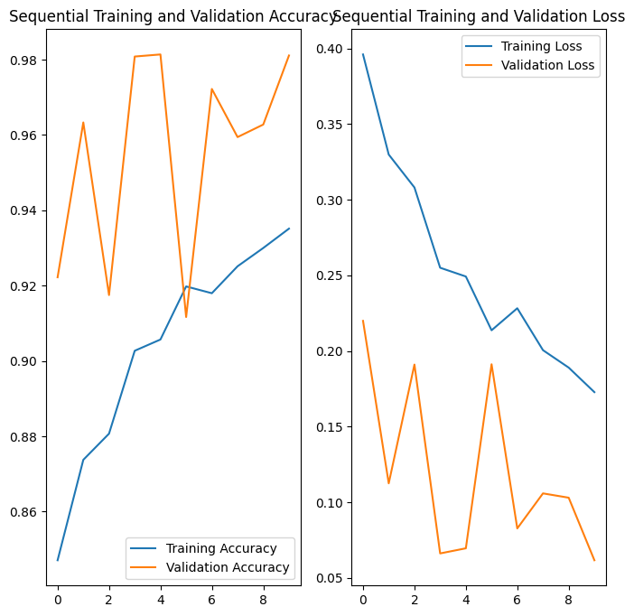

```python
seq_acc = seq_history.history['accuracy']
seq_test_acc = seq_history.history['val_accuracy']

seq_loss = seq_history.history['loss']
seq_test_loss = seq_history.history['val_loss']
seq_erange = range(10)

plt.figure(figsize=(8, 8))
plt.subplot(1, 2, 1)
plt.plot(seq_erange, seq_acc, label='Training Accuracy')
plt.plot(seq_erange, seq_test_acc, label='Validation Accuracy')
plt.legend(loc='lower right')
plt.title('Sequential Training and Validation Accuracy')

plt.subplot(1, 2, 2)
plt.plot(seq_erange, seq_loss, label='Training Loss')
plt.plot(seq_erange, seq_test_loss, label='Validation Loss')
plt.legend(loc='upper right')
plt.title('Sequential Training and Validation Loss')
plt.show()
```

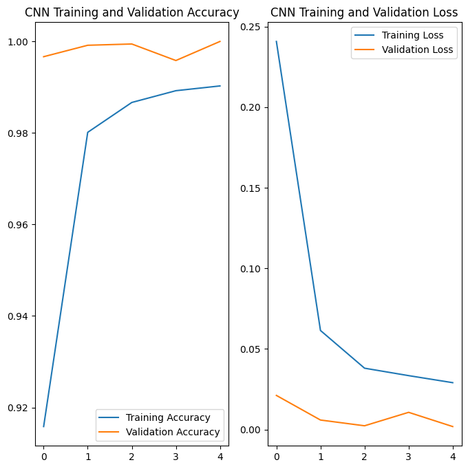

```python
cnn_acc = cnn_history.history['accuracy']
cnn_test_acc = cnn_history.history['val_accuracy']

cnn_loss = cnn_history.history['loss']
cnn_test_loss = cnn_history.history['val_loss']
cnn_erange = range(5)

plt.figure(figsize=(8, 8))
plt.subplot(1, 2, 1)
plt.plot(cnn_erange, cnn_acc, label='Training Accuracy')
plt.plot(cnn_erange, cnn_test_acc, label='Validation Accuracy')
plt.legend(loc='lower right')
plt.title('CNN Training and Validation Accuracy')

plt.subplot(1, 2, 2)
plt.plot(cnn_erange, cnn_loss, label='Training Loss')
plt.plot(cnn_erange, cnn_test_loss, label='Validation Loss')
plt.legend(loc='upper right')
plt.title('CNN Training and Validation Loss')
plt.show()
```

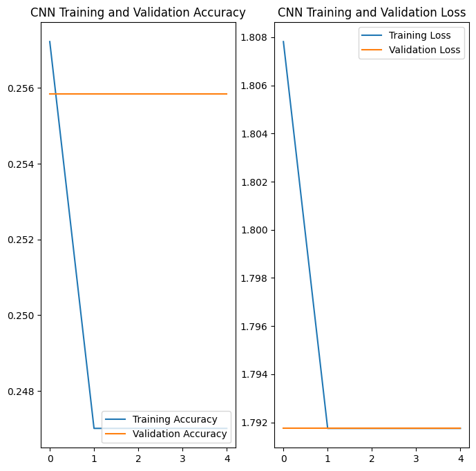

```python
pretrained_acc = pretrained_history.history['accuracy']
pretrained_test_acc = pretrained_history.history['val_accuracy']

pretrained_loss = pretrained_history.history['loss']
pretrained_test_loss = pretrained_history.history['val_loss']
pretrained_erange = range(5)

plt.figure(figsize=(8, 8))
plt.subplot(1, 2, 1)
plt.plot(pretrained_erange, pretrained_acc, label='Training Accuracy')
plt.plot(pretrained_erange, pretrained_test_acc, label='Validation Accuracy')
plt.legend(loc='lower right')
plt.title('CNN Training and Validation Accuracy')

plt.subplot(1, 2, 2)
plt.plot(pretrained_erange, pretrained_loss, label='Training Loss')
plt.plot(pretrained_erange, pretrained_test_loss, label='Validation Loss')
plt.legend(loc='upper right')
plt.title('CNN Training and Validation Loss')
plt.show()
```

These are the evaluations of each model on the test set.

```python
seq_eval_loss, seq_eval_acc = seq.evaluate(test_ds)
print('Sequential Test Evaluation Loss:',seq_eval_loss)
print('Sequential Test Evaluation Accuracy:',seq_eval_acc)
```

```
Sequential Test Evaluation Loss: 0.07425636053085327
Sequential Test Evaluation Accuracy: 0.971666693687439
```

```python
cnn_eval_loss, cnn_eval_acc = cnn.evaluate(test_ds)
print('CNN Test Evaluation Loss:',cnn_eval_loss)
print('CNN Test Evaluation Accuracy:',cnn_eval_acc)
```

```
CNN Test Evaluation Loss: 0.0011581633007153869
CNN Test Evaluation Accuracy: 1.0
```

```python
pretrained_eval_loss, pretrained_eval_acc = pretrained.evaluate(test_ds)
print('Pretrained Test Evaluation Loss:',pretrained_eval_loss)
print('Pretrained Test Evaluation Accuracy:',pretrained_eval_acc)
```

```
Pretrained Test Evaluation Loss: 1.7917604446411133
Pretrained Test Evaluation Accuracy: 0.25361111760139465
```

As seen here, the best perfroming model was the cnn. this is not too surprising as this data set is meant for cnn image classification and is very clean. The sequential model performed much better than I thought it would though which is interesting. The pretrained model just would not perform well. I tried many differnt configurations and such and nothing I did could get it over the 25% accuracy. I dont know why it just didnt perform as well.

This is the final thing i did more for fun than anything. I created a single image of my hand with 2 fingers up as shown. Ironically, the pretrained model is the only one to predict correctly. I do not think this is a good test though as my image is really not in the same format as the images in the data set nor is it of the same quality. This was more for my own curiosity that actual evaluation.

```
Sequential Model Predicted Class: 5 (98.02)
CNN Model Predicted Class: 3 (99.83)
Pretrained Model Predicted Class: 2 (74.51)
```

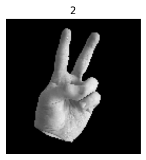

```python
test_image = k.utils.load_img('data/my_hand_2.png', target_size=(image_width, image_height))
test_image = k.utils.img_to_array(test_image)
test_image = tf.expand_dims(test_image, 0)

plt.figure(figsize=(3,3))
plt.imshow(test_image[0].numpy().astype("uint8"))
plt.title(class_names[2])
plt.axis("off")

seq_pred = seq.predict(test_image)
cnn_pred = cnn.predict(test_image)
pretrained_pred = pretrained.predict(test_image)

seq_score = tf.nn.softmax(seq_pred[0])
cnn_score = tf.nn.softmax(cnn_pred[0])
pretrained_score = tf.nn.softmax(pretrained_pred[0])

print("Sequential Model Predicted Class: {} ({:.2f})".format(class_names[np.argmax(seq_score)], 100 * np.max(seq_score)))
print("CNN Model Predicted Class: {} ({:.2f})".format(class_names[np.argmax(cnn_score)], 100 * np.max(cnn_score)))
print("Pretrained Model Predicted Class: {} ({:.2f})".format(class_names[np.argmax(pretrained_score)], 100 * np.max(pretrained_score)))
```